# FAIRmaterials

Authors:  
Jonathan E. Gordon$^{1}$, Alexander Harding Bradley$^{1}$, Priyan Rajamohan$^{1}$, Nathaniel Hahn$^{1}$, Kiefer Lin$^{1}$,  
Arafath Nihar$^{1}$, Hayden Cadwell$^{1}$, Jiana Kambo$^{1}$, Jayvic Jimenez$^{1}$, Kristen J. Hernandez$^{1}$, Hein Htet Aung$^{1}$,  
Brian Giera$^{2}$, Weiqi Yu$^{1}$, Mohommad Redad Mehdi$^{1}$, Finley Holt$^{1}$, Quynh Tran$^{1}$, Gabriel Ponon$^{1}$,  
Dan Savage$^{3}$, Don Brown$^{3}$, Jarod Kaltenbaugh$^{4}$, Kush Havinal$^{4}$, Nicholas Gray$^{4}$, Max Ligget$^{1}$,  
Benjamin G. Pierce$^{1}$, Raymond Wieser$^{1}$, Yangxin Fan$^{1}$, Tommy Ciardi$^{1}$, Olatunde J. Akanbi$^{1}$, Hadiza Iawal$^{1}$,  
Will Oltjen$^{1}$, Maliesha Kalutotage$^{1}$, Antony Lino$^{1}$, Van Tran$^{1}$, Mingjian Lu$^{1}$, Xuanji Yu$^{1}$,  
Abhishek Daundkar$^{1}$, Hope Omodolor$^{1}$, Mirra Rasmussen$^{1}$, Sameera Nalin-Venkat$^{1}$, Tian Wang$^{1}$,  
Rounak Chawla$^{1}$, Liangyi Huang$^{1}$, Zelin Li$^{1}$, Leean Jo$^{1}$, Jeffrey M. Yarus$^{1}$, Mengjie Li$^{4}$,  
Kristopher O. Davis$^{4}$, Yinghui Wu$^{1}$, Pawan K. Tripathi$^{1}$, Laura S. Bruckman$^{1}$, Erika I. Barcelos$^{1}$,  
Roger H. French$^{1}$  
$^{1}$ Materials Data Science for Stockpile Stewardship Center of Excellence, Cleveland, OH 44106, USA  
$^{2}$ Lawrence Livermore National Laboratory, Livermore, CA 94551, USA  
$^{3}$ Los Alamos National Laboratory, Los Alamos, NM 87545, USA  
$^{4}$ University of Central Florida, Materials Science & Engineering, Orlando, FL 32816, USA

# What is FAIRmaterials and what does it do?

‘FAIRmaterials’ is a bilingual package in R and Python that translates several CSV files from the template (described below) with ontological terms and corresponding data into RDF triples. These RDF triples are then stored in OWL and JSON-LD files, facilitating data accessibility, interoperability, and knowledge unification. The triples are also visualized in a graph saved as an SVG or as a PNG with the Python package. The Python package has a fourth output too. It generates documentation for the output ontology as an HTML.

Put the sheets, created from the template (described below), for one or more ontologies in a folder and the ‘FAIRmaterials’ ‘process_ontology_files’ or ‘FAIRSheetParser’ function will output a JSON-LD, turtle/OWL, SVG/PNG visualization, and HTML documentation into the input folder for all the input ontologies merged. Note that a folder containing only files for one ontology will give results for just that ontology and specifying a base uri is required for merging ontologies. The package can handle subdirectories by producing separate unmerged outputs for each subdirectory and a merged output from all files in the input path. This tool, developed for use by the SDLE Research Center at Case Western Reserve University, facilitates the creation and visualization of material science ontologies.

# How to use FAIR CSV template:

To Prepare your CSV files, ensure your CSV files contains the appropriate ontological terms and corresponding data using this template: [FAIR CSV Template](https://docs.google.com/spreadsheets/d/1k7gFRc1Yslc-m65aWfFCxqk5UtrKZl9c3GyEFQvLSFU/edit?usp=drive_link)

The XLSX versions of the templates can be found in the package using this code:

```r
# Load the necessary library
library(utils)

# Specifying the path to the Zip file
zip_file <- system.file("extdata", "FAIRSheetTemplatesZIP.zip", package = "FAIRmaterials")

# Extract files from the Zip
unzip(zip_file, exdir = "path/to/destination/for/templates")
```

## Example of XRay ontology FAIR CSV sheet

Example Name Space Sheet:

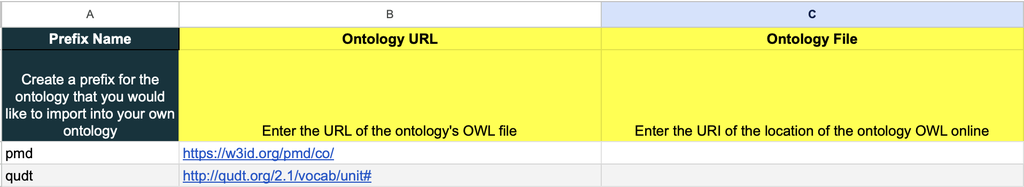

Example Ontology Information Sheet:

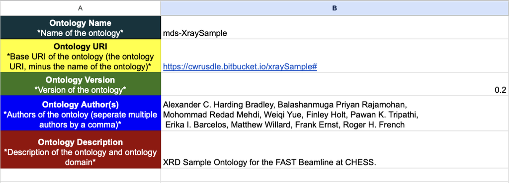

Example Variable Definitions Sheet:

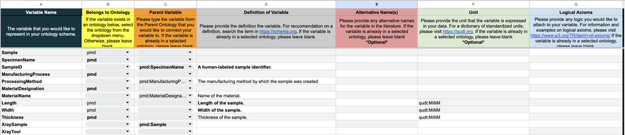

Example Relationship Definitions Sheet:

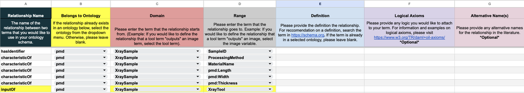

Example Value Type Definitions Sheet:

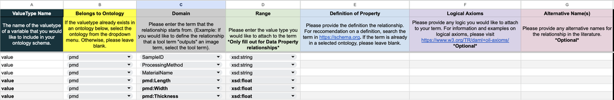

The descriptions under the column names provide instructions for how to fill out each column. Once the Name Space, Value Type Definitions, Relationship Definitions, Variable Definitions, and Ontology Info sheets are filled out, ‘FAIRmaterials’ is ready to use. The visualizations generated by this package are helpful to visualize an ontology to ensure satisfaction with the information in the sheets.

# Install and load the package

Install in R:

```r
install.packages("FAIRmaterials")

library(FAIRmaterials)
```

Install in Python:

```python
pip install FAIRmaterials
```

# Running the default ‘process_ontology_files’ function:

## PV ontology sheets:

Running the package in R:

```r
# Process the CSV files in the PV folder
example_folder1 <- system.file("extdata", "PV", package = "FAIRmaterials")
FAIRmaterials::process_ontology_files(example_folder1, add_external_onto_info = FALSE)
```

This visualization from the R package will be saved in the output folder as an SVG:

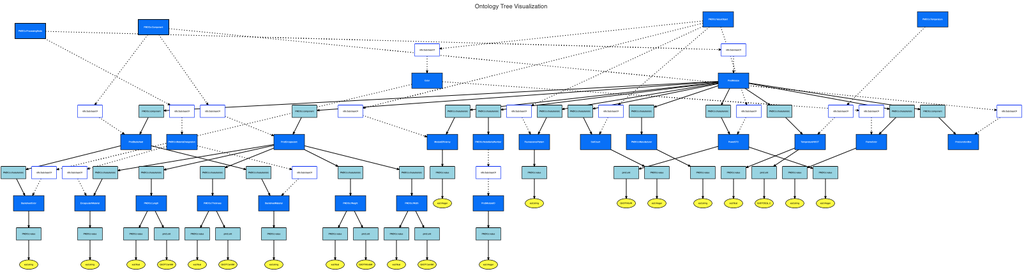

PV Visualization with Value Types

### turtle/owl output from PV Module in R:

**Click to expand PV Module owl file**

```
@prefix rdf: <http://www.w3.org/1999/02/22-rdf-syntax-ns#> .
@prefix sd: <http://www.w3.org/2001/XMLSchema#> .
@prefix owl: <http://www.w3.org/2002/07/owl#> .
@prefix rdfs: <http://www.w3.org/2000/01/rdf-schema#> .
@prefix skos: <http://www.w3.org/2004/02/skos/core#> .
@prefix pmd: <https://w3id.org/pmd/co/> .
@prefix PMDCo: <https://w3id.org/pmd/co#> .
@prefix QUDT: <https://qudt.org/vocab/unit/> .
@prefix dcterms: <http://purl.org/dc/terms/> .
@prefix PVModuleOntology: <https://cwrusdle.bitbucket.io/PVModuleOntology/> .

PVModuleOntology:BacksheetColor
    rdf:label "BacksheetColor" ;
    a rdfs:Class ;
    rdfs:comment "Color of the backsheet" ;
    rdfs:subClassOf PVModuleOntology:Color ;
    skos:altLabel "_" ;
    PMDCo:unit "_" .

PVModuleOntology:BacksheetMaterial
    rdf:label "BacksheetMaterial" ;
    a rdfs:Class ;
    rdfs:comment "Material the backsheet is made out of" ;
    rdfs:subClassOf PMDCo:MaterialDesignation ;
    skos:altLabel "_" ;
    PMDCo:unit "_" .

PVModuleOntology:CellCount
    rdf:label "CellCount" ;
    a rdfs:Class ;
    rdfs:comment "The number of cells in a module" ;
    rdfs:subClassOf PMDCo:ValueObject ;
    skos:altLabel "_" ;
    PMDCo:unit "_" .

PVModuleOntology:Color
    rdf:label "Color" ;
    a rdfs:Class ;
    rdfs:comment "the visual perception based on the electromagnetic spectrum" ;
    rdfs:subClassOf PMDCo:ValueObject ;
```

[output cut: 178 more lines]

```

PMDCo:characteristic
    a owl:ObjectProperty ;
    rdfs:domain PVModuleOntology:ProdBacksheet, PVModuleOntology:ProdEncapsulant, PVModuleOntology:ProdModule ;
    rdfs:range PVModuleOntology:BacksheetColor, PVModuleOntology:BacksheetMaterial, PVModuleOntology:CellCount, PVModuleOntology:EncapsulantMaterial, PVModuleOntology:FluorescencePattern, PVModuleOntology:FrameColor, PVModuleOntology:ModuleEfficiency, PVModuleOntology:PowerSTC, PVModuleOntology:Temp…

PMDCo:component
    a owl:ObjectProperty ;
    rdfs:domain PVModuleOntology:ProdModule ;
    rdfs:range PVModuleOntology:ProdBacksheet, PVModuleOntology:ProdEncapsulant, PVModuleOntology:ProdJunctionBox .

PMDCo:value
    a owl:DatatypeProperty ;
    rdfs:domain PVModuleOntology:BacksheetColor, PVModuleOntology:BacksheetMaterial, PVModuleOntology:CellCount, PVModuleOntology:EncapsulantMaterial, PVModuleOntology:FluorescencePattern, PVModuleOntology:FrameColor, PVModuleOntology:ModuleEfficiency, PVModuleOntology:PowerSTC, PVModuleOntology:Pro…
    rdfs:range sd:float, sd:integer, sd:string .
```

### json-ld output from PV Module in R:

**Click to expand PV Module json-ld output**

```
{
  "@graph": [
    {
      "@id": "https://cwrusdle.bitbucket.io/PVModuleOntology/BacksheetColor",
      "@type": "http://www.w3.org/2000/01/rdf-schema#Class",
      "http://www.w3.org/1999/02/22-rdf-syntax-ns#label": "BacksheetColor",
      "http://www.w3.org/2000/01/rdf-schema#comment": "Color of the backsheet",
      "http://www.w3.org/2000/01/rdf-schema#subClassOf": {
        "@id": "https://cwrusdle.bitbucket.io/PVModuleOntology/Color"
      },
      "http://www.w3.org/2004/02/skos/core#altLabel": "_",
      "https://w3id.org/pmd/co#unit": "_"
    },
    {
      "@id": "https://cwrusdle.bitbucket.io/PVModuleOntology/BacksheetMaterial",
      "@type": "http://www.w3.org/2000/01/rdf-schema#Class",
      "http://www.w3.org/1999/02/22-rdf-syntax-ns#label": "BacksheetMaterial",
      "http://www.w3.org/2000/01/rdf-schema#comment": "Material the backsheet is made out of",
      "http://www.w3.org/2000/01/rdf-schema#subClassOf": {
        "@id": "https://w3id.org/pmd/co#MaterialDesignation"
      },
      "http://www.w3.org/2004/02/skos/core#altLabel": "_",
      "https://w3id.org/pmd/co#unit": "_"
    },
    {
      "@id": "https://cwrusdle.bitbucket.io/PVModuleOntology/CellCount",
      "@type": "http://www.w3.org/2000/01/rdf-schema#Class",
      "http://www.w3.org/1999/02/22-rdf-syntax-ns#label": "CellCount",
      "http://www.w3.org/2000/01/rdf-schema#comment": "The number of cells in a module",
      "http://www.w3.org/2000/01/rdf-schema#subClassOf": {
        "@id": "https://w3id.org/pmd/co#ValueObject"
      },
      "http://www.w3.org/2004/02/skos/core#altLabel": "_",
      "https://w3id.org/pmd/co#unit": "_"
    },
    {
      "@id": "https://cwrusdle.bitbucket.io/PVModuleOntology/Color",
      "@type": "http://www.w3.org/2000/01/rdf-schema#Class",
      "http://www.w3.org/1999/02/22-rdf-syntax-ns#label": "Color",
      "http://www.w3.org/2000/01/rdf-schema#comment": "the visual perception based on the electromagnetic spectrum",
```

[output cut: 370 more lines]

```
      ],
      "http://www.w3.org/2000/01/rdf-schema#range": [
        {
          "@id": "http://www.w3.org/2001/XMLSchema#float"
        },
        {
          "@id": "http://www.w3.org/2001/XMLSchema#string"
        },
        {
          "@id": "http://www.w3.org/2001/XMLSchema#integer"
        }
      ]
    }
  ]
}
```

Running the package in Python:

```python
python -m FAIRmaterials --folder_path /path/to/csv/files --include_graph_valuetype --include_pylode_docs
```

This visualization from the Python package will be saved in the output folder as an PNG:

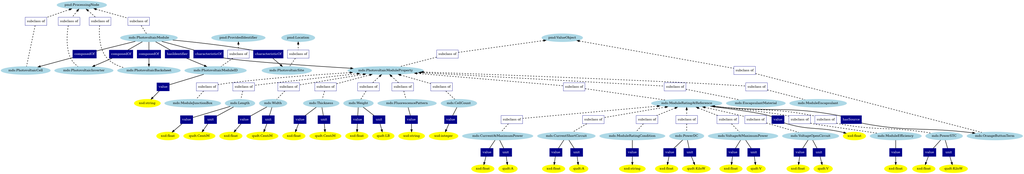

PV Visualization with Value Types

### HTML output

The HTML output generated by the Python package for PV Module can be found [here](https://cwrusdle.bitbucket.io/PylodeHTML/mds-pvModule-pylode.html):

### turtle/owl output from PV Module:

**Click to expand PV Module owl file**

```
@prefix dcterms: <http://purl.org/dc/terms/> .
@prefix mds-pvModule: <https://cwrusdle.bitbucket.io/pvModule#> .
@prefix owl: <http://www.w3.org/2002/07/owl#> .
@prefix pmd: <https://w3id.org/pmd/co/> .
@prefix qudt: <http://qudt.org/2.1/vocab/unit#> .
@prefix rdfs: <http://www.w3.org/2000/01/rdf-schema#> .
@prefix skos: <http://www.w3.org/2004/02/skos/core#> .
@prefix xsd: <http://www.w3.org/2001/XMLSchema#> .

mds-pvModule:EncapsulantMaterial a owl:Class ;
    rdfs:label "EncapsulantMaterial" ;
    rdfs:subClassOf mds-pvModule:PhotovoltaicModuleProperty ;
    skos:altLabel "" ;
    skos:definition "Material of the polymer encapsulant" .

mds-pvModule:ModuleEncapsulant a owl:Class ;
    rdfs:label "ModuleEncapsulant" ;
    rdfs:subClassOf mds-pvModule:PhotovoltaicModuleProperty ;
    skos:altLabel "" ;
    skos:definition "Polymer encapsulant of a module" .

mds-pvModule:ModuleJunctionBox a owl:Class ;
    rdfs:label "ModuleJunctionBox" ;
    rdfs:subClassOf mds-pvModule:PhotovoltaicModuleProperty ;
    skos:altLabel "" ;
    skos:definition "Electrical junction box for connection to the module" .

mds-pvModule:Ontology a owl:Ontology ;
    rdfs:label "mds-pvModule" ;
    dcterms:creator "Alexander C. Harding Bradley",
        "Balashanmuga Priyan Rajamohan",
        "Erika I. Barcelos",
        "Finley Holt",
        "Frank Ernst",
        "Matthew Willard",
        "Mohommad Redad Mehdi",
        "Pawan K. Tripathi",
        "Roger H. French",
        "Weiqi Yue" ;
    dcterms:description "An ontology describing a PV Module" ;
```

[output cut: 191 more lines]

```
pmd:ProcessingNode a owl:Class ;
    rdfs:label "ProcessingNode" ;
    skos:altLabel "" .

mds-pvModule:ModuleRatingAtReference a owl:Class ;
    rdfs:label "ModuleRatingAtReference" ;
    rdfs:subClassOf mds-pvModule:PhotovoltaicModuleProperty ;
    skos:altLabel "" ;
    skos:definition "Measurements of a module taken at STC and 1000 W/m^2 irradiance" .

mds-pvModule:PhotovoltaicModuleProperty a owl:Class ;
    rdfs:label "PhotovoltaicModuleProperty" ;
    rdfs:subClassOf pmd:ValueObject ;
    skos:altLabel "" ;
    skos:definition "A property of a PV module" .
```

### json-ld output from PV Module:

**Click to expand PV json-ld output**

```
{
  "@context": {
    "brick": "https://brickschema.org/schema/Brick#",
    "csvw": "http://www.w3.org/ns/csvw#",
    "dc": "http://purl.org/dc/elements/1.1/",
    "dcam": "http://purl.org/dc/dcam/",
    "dcat": "http://www.w3.org/ns/dcat#",
    "dcmitype": "http://purl.org/dc/dcmitype/",
    "dcterms": "http://purl.org/dc/terms/",
    "doap": "http://usefulinc.com/ns/doap#",
    "foaf": "http://xmlns.com/foaf/0.1/",
    "geo": "http://www.opengis.net/ont/geosparql#",
    "mds-pvModule": "https://cwrusdle.bitbucket.io/pvModule#",
    "odrl": "http://www.w3.org/ns/odrl/2/",
    "org": "http://www.w3.org/ns/org#",
    "owl": "http://www.w3.org/2002/07/owl#",
    "pmd": "https://w3id.org/pmd/co/",
    "prof": "http://www.w3.org/ns/dx/prof/",
    "prov": "http://www.w3.org/ns/prov#",
    "qb": "http://purl.org/linked-data/cube#",
    "qudt": "http://qudt.org/2.1/vocab/unit#",
    "rdf": "http://www.w3.org/1999/02/22-rdf-syntax-ns#",
    "rdfs": "http://www.w3.org/2000/01/rdf-schema#",
    "schema": "https://schema.org/",
    "sh": "http://www.w3.org/ns/shacl#",
    "skos": "http://www.w3.org/2004/02/skos/core#",
    "sosa": "http://www.w3.org/ns/sosa/",
    "ssn": "http://www.w3.org/ns/ssn/",
    "time": "http://www.w3.org/2006/time#",
    "vann": "http://purl.org/vocab/vann/",
    "void": "http://rdfs.org/ns/void#",
    "wgs": "https://www.w3.org/2003/01/geo/wgs84_pos#",
    "xml": "http://www.w3.org/XML/1998/namespace",
    "xsd": "http://www.w3.org/2001/XMLSchema#"
  },
  "@graph": [
    {
      "@id": "mds-pvModule:VoltageOpenCircuit",
      "@type": "owl:Class",
      "pmd:unit": {
```

[output cut: 435 more lines]

```
      "rdfs:label": "ProvidedIdentifier",
      "skos:altLabel": ""
    },
    {
      "@id": "mds-pvModule:PhotovoltaicCell",
      "@type": "owl:Class",
      "rdfs:label": "PhotovoltaicCell",
      "rdfs:subClassOf": {
        "@id": "pmd:ProcessingNode"
      },
      "skos:altLabel": "",
      "skos:definition": "PV cell that composes a module"
    }
  ]
}
```

## XRay Sample ontology sheets:

Running the package in R:

```r
# Process the CSV files in the Xray folder
example_folder2 <- system.file("extdata", "XRay", package = "FAIRmaterials")
FAIRmaterials::process_ontology_files(example_folder2, add_external_onto_info = FALSE)
```

This visualization from the R package will be saved in the output folder as an SVG:

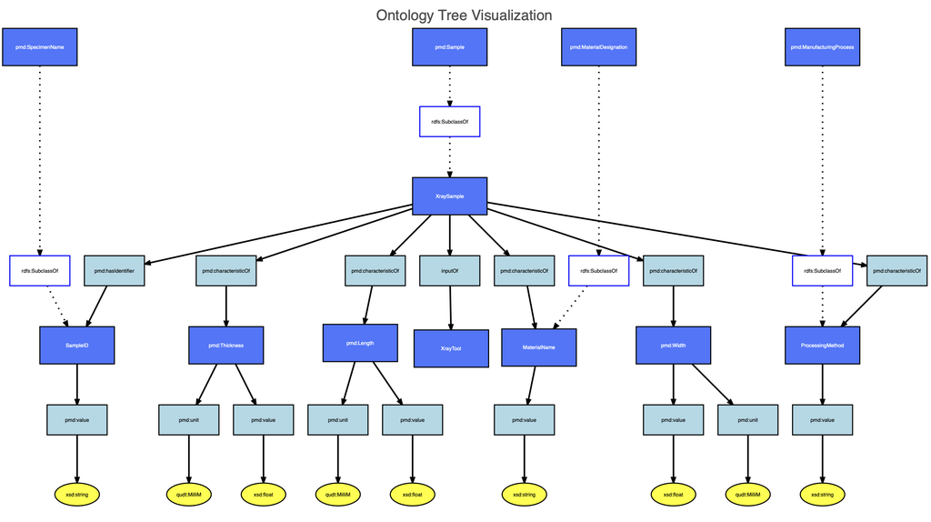

XRay Visualization with Value Types

### turtle/owl output from XRay Sample in R:

**Click to expand XRay Sample owl file**

```
@prefix rdf: <http://www.w3.org/1999/02/22-rdf-syntax-ns#> .
@prefix qudt: <http://qudt.org/2.1/vocab/unit#> .
@prefix sd: <http://www.w3.org/2001/XMLSchema#> .
@prefix owl: <http://www.w3.org/2002/07/owl#> .
@prefix rdfs: <http://www.w3.org/2000/01/rdf-schema#> .
@prefix skos: <http://www.w3.org/2004/02/skos/core#> .
@prefix pmd: <https://w3id.org/pmd/co/> .
@prefix PMDCo: <https://w3id.org/pmd/co#> .
@prefix QUDT: <https://qudt.org/vocab/unit/> .
@prefix dcterms: <http://purl.org/dc/terms/> .
@prefix mds-XraySample: <https://cwrusdle.bitbucket.io/xraySample#> .

mds-XraySample:MaterialName
    rdf:label "MaterialName" ;
    a rdfs:Class ;
    rdfs:comment "Name of the material." ;
    rdfs:subClassOf pmd:MaterialDesignation ;
    skos:altLabel "_" ;
    PMDCo:unit "_" .

mds-XraySample:Ontology
    dcterms:creator """Alexander C. Harding Bradley, Balashanmuga Priyan Rajamohan,
Mohommad Redad Mehdi, Weiqi Yue, Finley Holt, Pawan K. Tripathi,
 Erika I. Barcelos, Matthew Willard, Frank Ernst, Roger H. French""" ;
    dcterms:description "XRD Sample Ontology for the FAST Beamline at CHESS." ;
    dcterms:title "mds-XraySample" ;
    rdf:label <https://cwrusdle.bitbucket.io/xraySample#> ;
    a owl:Ontology ;
    owl:versionInfo "0.2" .

mds-XraySample:ProcessingMethod
    rdf:label "ProcessingMethod" ;
    a rdfs:Class ;
    rdfs:comment "The manufacturing method by ehich the sample was created." ;
    rdfs:subClassOf pmd:ManufacturingProcess ;
    skos:altLabel "_" ;
    PMDCo:unit "_" .

mds-XraySample:SampleID
    rdf:label "SampleID" ;
```

[output cut: 74 more lines]

```

pmd:characteristicOf
    a owl:ObjectProperty ;
    rdfs:domain mds-XraySample:XraySample ;
    rdfs:range mds-XraySample:MaterialName, mds-XraySample:ProcessingMethod, pmd:Length, pmd:Thickness, pmd:Width .

pmd:hasIdentifier
    a owl:ObjectProperty ;
    rdfs:domain mds-XraySample:XraySample ;
    rdfs:range mds-XraySample:SampleID .

pmd:value
    a owl:DatatypeProperty ;
    rdfs:domain mds-XraySample:MaterialName, mds-XraySample:ProcessingMethod, mds-XraySample:SampleID, pmd:Length, pmd:Thickness, pmd:Width ;
    rdfs:range sd:float, sd:string .
```

### json-ld output from XRay Sample in R:

**Click to expand XRay Sample json-ld output**

```
{
  "@graph": [
    {
      "@id": "https://cwrusdle.bitbucket.io/xraySample#MaterialName",
      "@type": "http://www.w3.org/2000/01/rdf-schema#Class",
      "http://www.w3.org/1999/02/22-rdf-syntax-ns#label": "MaterialName",
      "http://www.w3.org/2000/01/rdf-schema#comment": "Name of the material.",
      "http://www.w3.org/2000/01/rdf-schema#subClassOf": {
        "@id": "https://w3id.org/pmd/co/MaterialDesignation"
      },
      "http://www.w3.org/2004/02/skos/core#altLabel": "_",
      "https://w3id.org/pmd/co#unit": "_"
    },
    {
      "@id": "https://cwrusdle.bitbucket.io/xraySample#Ontology",
      "@type": "http://www.w3.org/2002/07/owl#Ontology",
      "http://purl.org/dc/terms/creator": "Alexander C. Harding Bradley, Balashanmuga Priyan Rajamohan, \nMohommad Redad Mehdi, Weiqi Yue, Finley Holt, Pawan K. Tripathi, \n Erika I. Barcelos, Matthew Willard, Frank Ernst, Roger H. French",
      "http://purl.org/dc/terms/description": "XRD Sample Ontology for the FAST Beamline at CHESS.",
      "http://purl.org/dc/terms/title": "mds-XraySample",
      "http://www.w3.org/1999/02/22-rdf-syntax-ns#label": {
        "@id": "https://cwrusdle.bitbucket.io/xraySample#"
      },
      "http://www.w3.org/2002/07/owl#versionInfo": "0.2"
    },
    {
      "@id": "https://cwrusdle.bitbucket.io/xraySample#ProcessingMethod",
      "@type": "http://www.w3.org/2000/01/rdf-schema#Class",
      "http://www.w3.org/1999/02/22-rdf-syntax-ns#label": "ProcessingMethod",
      "http://www.w3.org/2000/01/rdf-schema#comment": "The manufacturing method by ehich the sample was created.",
      "http://www.w3.org/2000/01/rdf-schema#subClassOf": {
        "@id": "https://w3id.org/pmd/co/ManufacturingProcess"
      },
      "http://www.w3.org/2004/02/skos/core#altLabel": "_",
      "https://w3id.org/pmd/co#unit": "_"
    },
    {
      "@id": "https://cwrusdle.bitbucket.io/xraySample#SampleID",
      "@type": "http://www.w3.org/2000/01/rdf-schema#Class",
      "http://www.w3.org/1999/02/22-rdf-syntax-ns#label": "SampleID",
      "http://www.w3.org/2000/01/rdf-schema#comment": "A human-labeled sample identifier.",
```

[output cut: 150 more lines]

```
        {
          "@id": "https://cwrusdle.bitbucket.io/xraySample#SampleID"
        }
      ],
      "http://www.w3.org/2000/01/rdf-schema#range": [
        {
          "@id": "http://www.w3.org/2001/XMLSchema#float"
        },
        {
          "@id": "http://www.w3.org/2001/XMLSchema#string"
        }
      ]
    }
  ]
}
```

Running the package in Python:

```python
# Process the CSV files in the Xray folder
python -m FAIRmaterials --folder_path /path/to/csv/files --include_graph_valuetype --include_pylode_docs
```

This visualization from the Python package will be saved in the output folder as an PNG:

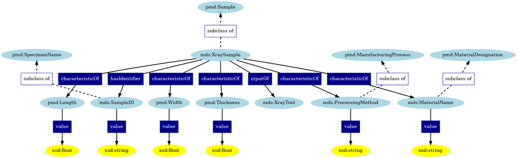

### HTML output

The HTML output generated by the Python package for XRay Sample can be found [here](https://cwrusdle.bitbucket.io/PylodeHTML/mds-XraySample-pylode.html):

**Click to expand XRay Sample owl file**

```
@prefix dcterms: <http://purl.org/dc/terms/> .
@prefix mds-XraySample: <https://cwrusdle.bitbucket.io/xraySample#> .
@prefix owl: <http://www.w3.org/2002/07/owl#> .
@prefix pmd: <https://w3id.org/pmd/co/> .
@prefix qudt: <http://qudt.org/2.1/vocab/unit#> .
@prefix rdfs: <http://www.w3.org/2000/01/rdf-schema#> .
@prefix skos: <http://www.w3.org/2004/02/skos/core#> .
@prefix xsd: <http://www.w3.org/2001/XMLSchema#> .

mds-XraySample:Ontology a owl:Ontology ;
    rdfs:label "mds-XraySample" ;
    dcterms:creator "Alexander C. Harding Bradley",
        "Balashanmuga Priyan Rajamohan",
        "Erika I. Barcelos",
        "Finley Holt",
        "Frank Ernst",
        "Matthew Willard",
        "Mohommad Redad Mehdi",
        "Pawan K. Tripathi",
        "Roger H. French",
        "Weiqi Yue" ;
    dcterms:description "XRD Sample Ontology for the FAST Beamline at CHESS." ;
    dcterms:title "mds-XraySample" ;
    owl:versionInfo "0.2" .

pmd:characteristicOf a owl:ObjectProperty ;
    rdfs:domain mds-XraySample:XraySample ;
    rdfs:range mds-XraySample:MaterialName,
        mds-XraySample:ProcessingMethod,
        pmd:Length,
        pmd:Thickness,
        pmd:Width .

pmd:hasIdentifier a owl:ObjectProperty ;
    rdfs:domain mds-XraySample:XraySample ;
    rdfs:range mds-XraySample:SampleID .

pmd:inputOf a owl:ObjectProperty ;
    rdfs:domain mds-XraySample:XraySample ;
    rdfs:range mds-XraySample:XrayTool .
```

[output cut: 56 more lines]

```
    rdfs:label "Thickness" ;
    skos:altLabel "" ;
    skos:definition "Thickness of the sample." ;
    pmd:unit qudt:MilliM .

pmd:Width a owl:Class ;
    rdfs:label "Width" ;
    skos:altLabel "" ;
    skos:definition "Width of the sample." ;
    pmd:unit qudt:MilliM .

mds-XraySample:XraySample a owl:Class ;
    rdfs:label "XraySample" ;
    rdfs:subClassOf pmd:Sample ;
    skos:altLabel "" .
```

**Click to expand XRay Sample json-ld output**

```
{
  "@context": {
    "brick": "https://brickschema.org/schema/Brick#",
    "csvw": "http://www.w3.org/ns/csvw#",
    "dc": "http://purl.org/dc/elements/1.1/",
    "dcam": "http://purl.org/dc/dcam/",
    "dcat": "http://www.w3.org/ns/dcat#",
    "dcmitype": "http://purl.org/dc/dcmitype/",
    "dcterms": "http://purl.org/dc/terms/",
    "doap": "http://usefulinc.com/ns/doap#",
    "foaf": "http://xmlns.com/foaf/0.1/",
    "geo": "http://www.opengis.net/ont/geosparql#",
    "mds-XraySample": "https://cwrusdle.bitbucket.io/xraySample#",
    "odrl": "http://www.w3.org/ns/odrl/2/",
    "org": "http://www.w3.org/ns/org#",
    "owl": "http://www.w3.org/2002/07/owl#",
    "pmd": "https://w3id.org/pmd/co/",
    "prof": "http://www.w3.org/ns/dx/prof/",
    "prov": "http://www.w3.org/ns/prov#",
    "qb": "http://purl.org/linked-data/cube#",
    "qudt": "http://qudt.org/2.1/vocab/unit#",
    "rdf": "http://www.w3.org/1999/02/22-rdf-syntax-ns#",
    "rdfs": "http://www.w3.org/2000/01/rdf-schema#",
    "schema": "https://schema.org/",
    "sh": "http://www.w3.org/ns/shacl#",
    "skos": "http://www.w3.org/2004/02/skos/core#",
    "sosa": "http://www.w3.org/ns/sosa/",
    "ssn": "http://www.w3.org/ns/ssn/",
    "time": "http://www.w3.org/2006/time#",
    "vann": "http://purl.org/vocab/vann/",
    "void": "http://rdfs.org/ns/void#",
    "wgs": "https://www.w3.org/2003/01/geo/wgs84_pos#",
    "xml": "http://www.w3.org/XML/1998/namespace",
    "xsd": "http://www.w3.org/2001/XMLSchema#"
  },
  "@graph": [
    {
      "@id": "pmd:value",
      "@type": "owl:DatatypeProperty",
      "rdfs:domain": [
```

[output cut: 178 more lines]

```
      "skos:altLabel": "",
      "skos:definition": "A human-labeled sample identifier."
    },
    {
      "@id": "pmd:hasIdentifier",
      "@type": "owl:ObjectProperty",
      "rdfs:domain": {
        "@id": "mds-XraySample:XraySample"
      },
      "rdfs:range": {
        "@id": "mds-XraySample:SampleID"
      }
    }
  ]
}
```

# Removing values from visualization in R

By setting include_graph_valuetype argument to FALSE the valuetypes are excluded from graph. We can see how this graph differs from the PV graph above.

Removing values in R:

```r
FAIRmaterials::process_ontology_files(example_folder1, include_graph_valuetype = FALSE, add_external_onto_info = FALSE)
```

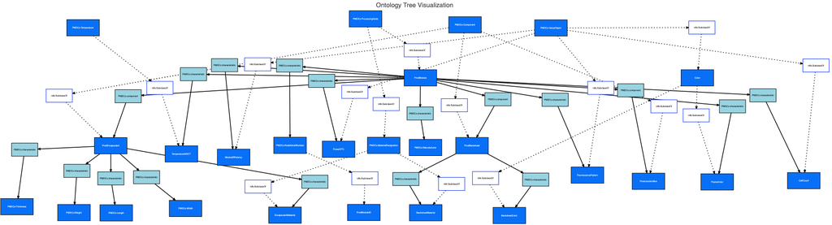

PV Visualization without Value Types

# Removing values from visualization in Python

Removing values in Python:

```python
python -m FAIRmaterials --folder_path /path/to/csv/files
```

This visualization from the Python package will be saved in the output folder as a PNG:

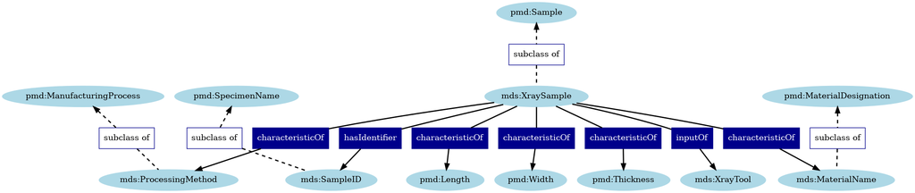

# Attempting to add external ontology information in R:

Now we set the add_external_onto_info argument to TRUE. The package attempts to find additional information for every term in the XRay Sample and PV Module data and update the output.

## For PV Module:

Adding external ontology information in R:

```r
FAIRmaterials::process_ontology_files(example_folder1, include_graph_valuetype = TRUE, add_external_onto_info = TRUE)
```

### turtle/owl output from PV Module:

**Click to expand updated PV Module owl file**

```
@prefix rdf: <http://www.w3.org/1999/02/22-rdf-syntax-ns#> .
@prefix sd: <http://www.w3.org/2001/XMLSchema#> .
@prefix owl: <http://www.w3.org/2002/07/owl#> .
@prefix rdfs: <http://www.w3.org/2000/01/rdf-schema#> .
@prefix skos: <http://www.w3.org/2004/02/skos/core#> .
@prefix pmd: <https://w3id.org/pmd/co/> .
@prefix PMDCo: <https://w3id.org/pmd/co#> .
@prefix QUDT: <https://qudt.org/vocab/unit/> .
@prefix dcterms: <http://purl.org/dc/terms/> .
@prefix PVModuleOntology: <https://cwrusdle.bitbucket.io/PVModuleOntology/> .

PVModuleOntology:BacksheetColor
    rdf:label "BacksheetColor" ;
    a rdfs:Class ;
    rdfs:comment "Color of the backsheet" ;
    rdfs:subClassOf PVModuleOntology:Color .

PVModuleOntology:BacksheetMaterial
    rdf:label "BacksheetMaterial" ;
    a rdfs:Class ;
    rdfs:comment "Material the backsheet is made out of" ;
    rdfs:subClassOf PMDCo:MaterialDesignation .

PVModuleOntology:CellCount
    rdf:label "CellCount" ;
    a rdfs:Class ;
    rdfs:comment "The number of cells in a module" ;
    rdfs:subClassOf PMDCo:ValueObject .

PVModuleOntology:Color
    rdf:label "Color" ;
    a rdfs:Class ;
    rdfs:comment "the visual perception based on the electromagnetic spectrum" ;
    rdfs:subClassOf PMDCo:ValueObject .

PVModuleOntology:EncapsulantMaterial
    rdf:label "EncapsulantMaterial" ;
    a rdfs:Class ;
    rdfs:comment "Material the encapsulant is made out of" ;
    rdfs:subClassOf PMDCo:MaterialDesignation .
```

[output cut: 236 more lines]

```
pmd:Weight
    a owl:Class ;
    rdfs:isDefinedBy <https://w3id.org/pmd/co> ;
    rdfs:label "Gewicht", "Weight" ;
    rdfs:subClassOf pmd:ValueObject ;
    skos:definition "The force with which a body is attracted toward the earth or a celestial body by gravitation and which is equal to the product of the mass and the local gravitational acceleration." ;
    pmd:definitionSource "“Weight.” Merriam-Webster.com Dictionary, Merriam-Webster, https://www.merriam-webster.com/dictionary/weight. Accessed 5 Dec. 2022." .

pmd:Width
    a owl:Class ;
    rdfs:isDefinedBy <https://w3id.org/pmd/co> ;
    rdfs:label "Breite", "Width" ;
    rdfs:subClassOf pmd:ValueObject ;
    skos:definition "Diese Entität bezeichnet eine horizontale Messung, die im rechten Winkel zur Länge eines Objekts vorgenommen wird.", "This entity describes a horizontal measurement of an object taken at right angles to the length of the object." ;
    pmd:definitionSource <https://www.merriam-webster.com/dictionary/width> .
```

We can see pmd:AgingTemperature and many of the of other pmd terms got more arguments pulled from https://w3id.org/pmd/co/.

## For XRay Sample:

Adding external ontology information in R:

```r
FAIRmaterials::process_ontology_files(example_folder2, include_graph_valuetype = TRUE, add_external_onto_info = TRUE)
```

### turtle/owl output from XRay Sample:

**Click to expand updated XRay Sample owl file**

```
@prefix rdf: <http://www.w3.org/1999/02/22-rdf-syntax-ns#> .
@prefix qudt: <http://qudt.org/2.1/vocab/unit#> .
@prefix sd: <http://www.w3.org/2001/XMLSchema#> .
@prefix owl: <http://www.w3.org/2002/07/owl#> .
@prefix rdfs: <http://www.w3.org/2000/01/rdf-schema#> .
@prefix skos: <http://www.w3.org/2004/02/skos/core#> .
@prefix pmd: <https://w3id.org/pmd/co/> .
@prefix PMDCo: <https://w3id.org/pmd/co#> .
@prefix QUDT: <https://qudt.org/vocab/unit/> .
@prefix dcterms: <http://purl.org/dc/terms/> .
@prefix mds-XraySample: <https://cwrusdle.bitbucket.io/xraySample#> .

mds-XraySample:MaterialName
    rdf:label "MaterialName" ;
    a rdfs:Class ;
    rdfs:comment "Name of the material." ;
    rdfs:subClassOf pmd:MaterialDesignation .

mds-XraySample:Ontology
    dcterms:creator """Alexander C. Harding Bradley, Balashanmuga Priyan Rajamohan,
Mohommad Redad Mehdi, Weiqi Yue, Finley Holt, Pawan K. Tripathi,
 Erika I. Barcelos, Matthew Willard, Frank Ernst, Roger H. French""" ;
    dcterms:description "XRD Sample Ontology for the FAST Beamline at CHESS." ;
    dcterms:title "mds-XraySample" ;
    rdf:label <https://cwrusdle.bitbucket.io/xraySample#> ;
    a owl:Ontology ;
    owl:versionInfo "0.2" .

mds-XraySample:ProcessingMethod
    rdf:label "ProcessingMethod" ;
    a rdfs:Class ;
    rdfs:comment "The manufacturing method by ehich the sample was created." ;
    rdfs:subClassOf pmd:ManufacturingProcess .

mds-XraySample:SampleID
    rdf:label "SampleID" ;
    a rdfs:Class ;
    rdfs:comment "A human-labeled sample identifier." ;
    rdfs:subClassOf pmd:SpecimenName .

```

[output cut: 80 more lines]

```

pmd:characteristicOf
    a owl:ObjectProperty ;
    rdfs:domain mds-XraySample:XraySample ;
    rdfs:range mds-XraySample:MaterialName, mds-XraySample:ProcessingMethod, pmd:Length, pmd:Thickness, pmd:Width .

pmd:hasIdentifier
    a owl:ObjectProperty ;
    rdfs:domain mds-XraySample:XraySample ;
    rdfs:range mds-XraySample:SampleID .

pmd:value
    a owl:DatatypeProperty ;
    rdfs:domain mds-XraySample:MaterialName, mds-XraySample:ProcessingMethod, mds-XraySample:SampleID, pmd:Length, pmd:Thickness, pmd:Width ;
    rdfs:range sd:float, sd:string .
```

We can see pmd:Length and many of the of other pmd terms more arguments pulled from https://w3id.org/pmd/co/.